# Aggregated Data and Incidence Rates

- Show All Code
- Hide All Code
- View Source

From cases to counts, and from counts to comparable rates

Author

Eric M. Delmelle · Lehigh University

**Get the source.** [Download `index.qmd`](https://github.com/BSTA-374/AggregatedRates/raw/main/index.qmd) — open it in RStudio and run the chunks alongside this page.

## Let’s back up a bit

In the first week of the semester, we discussed rates. When cases become counts, counts become rates, and rates become something that can fairly be compared across areas with different populations. This is related to **Assignment 4** and the input for most pattern analysis we will do afterwards: Moran’s I, cluster detection, and the Bayesian models all start from observed and expected counts.

Important reading: **Moraga 5.2**. We will be using the same Pennsylvania lung cancer data in the second part of this notebook.

```r
library(sf)
library(dplyr)
library(ggplot2)
library(patchwork)
library(SpatialEpi)   # pennLC data; expected()

theme_set(theme_classic(base_size = 12))
```

**Note**

If `SpatialEpi` is missing, `install.packages("SpatialEpi")` once.

# 1 From cases to counts

## 1.1 Why aggregate at all

Health data rarely arrive as the counts we map. They arrive as records: a diagnosis, a death certificate, an address. We (or epidemiologists) aggregate them to areas for three reasons. Denominators — the population at risk — exist only for areas, from the census. Confidentiality rules usually forbid releasing point locations. And most reporting (state registries, CDC WONDER) is area-based already.

## 1.2 Aggregating points: a worked example from North Carolina

```r
nc <- st_read(system.file("shape/nc.shp", package = "sf"), quiet = TRUE) |>
  st_transform(32119)                           # NC State Plane, metres

set.seed(374)
cases <- st_sample(nc, size = nc$SID74) |>      # one point per death
  st_sf() |>
  mutate(case_id = row_number())

nrow(cases)
```

```
[1] 671
```

Aggregation is a point-in-polygon operation. Before running it, one check that saves more grief than any other:

```r
st_crs(cases) == st_crs(nc)                     # must be TRUE
```

```
[1] TRUE
```

(note: If the two layers are in different CRSs, `sf` will stop you — but only if both CRSs are declared. A shapefile with a missing `.prj` fails silently).

### 1.2.1 Counting points in polygons

`st_intersects()` returns, for each county, the points inside it; `lengths()` counts them. Counties with no cases get a zero.

```r
nc$n_cases <- lengths(st_intersects(nc, cases))

sum(nc$n_cases)                                 # should equal nrow(cases)
```

```
[1] 671
```

## 1.3 Counts are not risk

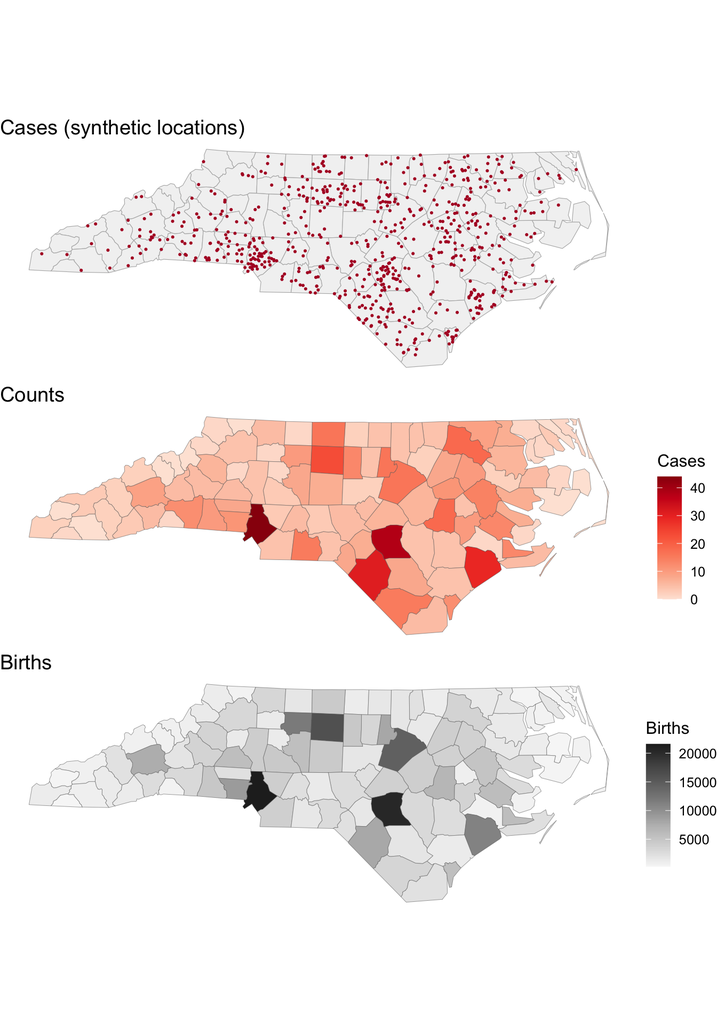

Figure 1: Case locations, county counts, and births. The counts mostly redraw the population.

```r
p1 <- ggplot() +
  geom_sf(data = nc, fill = "grey95", colour = "grey70", linewidth = 0.2) +
  geom_sf(data = cases, size = 0.4, colour = "#b2182b") +
  labs(title = "Cases (synthetic locations)")

p2 <- ggplot(nc) +
  geom_sf(aes(fill = n_cases), colour = "grey40", linewidth = 0.1) +
  scale_fill_distiller(palette = "Reds", direction = 1, name = "Cases") +
  labs(title = "Counts")

p3 <- ggplot(nc) +
  geom_sf(aes(fill = BIR74), colour = "grey40", linewidth = 0.1) +
  scale_fill_distiller(palette = "Greys", direction = 1, name = "Births") +
  labs(title = "Births")

p1 / p2 / p3 & theme_void(base_size = 12)
```

The count map is mostly a population map: Mecklenburg, Wake, and Guilford have many deaths because they have many births. A count needs a denominator before it says anything about risk — which is where the rest of today begins.

## 1.4 From counts to a crude rate

Dividing each county’s count by its births gives the crude SIDS rate:

$$\text{crude}_i = \frac{O_i}{\text{births}_i} \times 1{,}000$$

```r
nc <- nc |>
  mutate(crude = 1000 * n_cases / BIR74)        # per 1,000 births

1000 * sum(nc$n_cases) / sum(nc$BIR74)          # statewide rate
```

```
[1] 2.033568
```

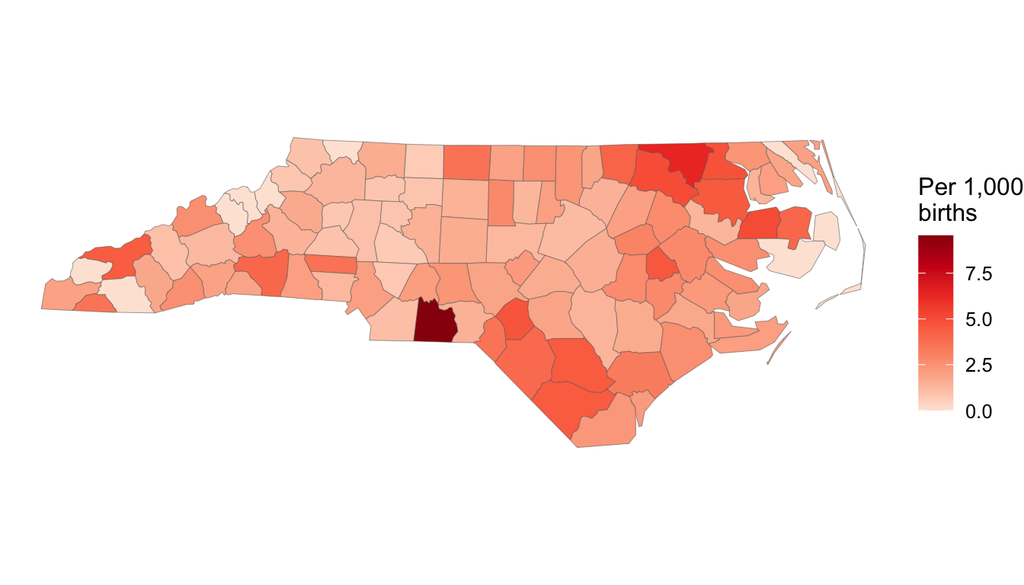

Figure 2: Crude SIDS rate per 1,000 live births, North Carolina 1974–78.

```r
ggplot(nc) +
  geom_sf(aes(fill = crude), colour = "grey40", linewidth = 0.1) +
  scale_fill_distiller(palette = "Reds", direction = 1, name = "Per 1,000\nbirths") +
  theme_void(base_size = 12)
```

The picture changes: the large urban counties no longer dominate. The highest rates are in small counties such as Anson (15 deaths among 1,570 births, 9.6 per 1,000) and Northampton, against a statewide rate of about 2.0. Rates built on so few births are unstable. —

# 2 Measures of disease frequency

## 2.1 Three measures, three questions

**Incidence** counts *new* cases arising in a population over a period of time. **Prevalence** counts *existing* cases at a point (or short window) in time (~cross-section, snapshot). **Mortality** counts deaths, and is an incidence measure whose event is death. For surveillance and aetiology we usually want incidence; prevalence mixes incidence with duration, so a disease that lasts longer looks more common even if it arises no more often.

Incidence itself comes in two forms, and the distinction matters for the denominator.

| Measure | Numerator | Denominator | Units |
| --- | --- | --- | --- |
| Cumulative incidence (risk) | new cases in period | population at risk at start | proportion, over a stated period |
| Incidence rate | new cases in period | **person-time** at risk | cases per person-year |
| Point prevalence | existing cases | total population | proportion |

## 2.2 Person-time

The incidence rate divides by the total time individuals spent at risk. Ten thousand people followed for five years contribute roughly 50,000 person-years; 50 new cases gives a rate of 1 per 1,000 person-years. For area data we never observe individual follow-up, so person-time is approximated as

$$\text{person-years}_i \approx \text{mid-period population}_i \times \text{years in period}.$$

For a single calendar year, the mid-year population *is* the person-time approximation, which is why annual registry rates are expressed “per 100,000 population”.

**WarningRead the denominator before the number**

The NC SIDS rate is deaths per 1,000 **live births** — a proportion of a birth cohort, not a rate per person-year. The 1974–78 and 1979–84 periods are five and six years long, yet their rates per 1,000 births are comparable because births, not years, are the denominator. Divide deaths by `BIR74 * 5` and you have produced a number with no clear meaning.

# 3 Crude rates

## 3.1 Pennsylvania lung cancer, 2002

The `pennLC` data give lung cancer cases and population for each of Pennsylvania’s 67 counties in 2002, split into **16 strata**: race (white, other), sex, and four age groups.

```r
data(pennLC)

d <- pennLC$data |>
  mutate(age = factor(age, levels = c("Under.40", "40.59", "60.69", "70+")))

head(d, 8)
```

| county | cases | population | race | gender | age |
| --- | --- | --- | --- | --- | --- |
| adams | 0 | 1492 | o | f | Under.40 |
| adams | 0 | 365 | o | f | 40.59 |
| adams | 1 | 68 | o | f | 60.69 |
| adams | 0 | 73 | o | f | 70+ |
| adams | 0 | 23351 | w | f | Under.40 |
| adams | 5 | 12136 | w | f | 40.59 |
| adams | 5 | 3609 | w | f | 60.69 |
| adams | 18 | 5411 | w | f | 70+ |

```r
pa <- st_as_sf(pennLC$spatial.polygon) |>
  st_set_crs(4326) |>
  mutate(county = names(pennLC$spatial.polygon))
```

The **crude rate** ignores strata: all cases over all people.

$$\text{crude}_i = \frac{O_i}{P_i} \times 100{,}000$$

```r
county <- d |>
  group_by(county) |>
  summarise(
    O    = sum(cases),                                         # observed
    pop  = sum(population),
    p60  = sum(population[age %in% c("60.69", "70+")]) / pop,  # share aged 60+
    .groups = "drop"
  ) |>
  mutate(crude = 1e5 * O / pop)

pa_rate <- 1e5 * sum(county$O) / sum(county$pop)               # statewide
pa_rate
```

```
[1] 83.69803
```

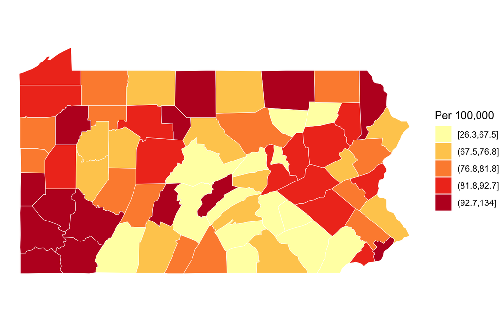

Figure 3: Crude lung cancer incidence per 100,000, Pennsylvania 2002 (quantile classes).

```r
pa_map <- pa |> left_join(county, by = "county")

ggplot(pa_map) +
  geom_sf(aes(fill = cut(crude, quantile(crude, 0:5 / 5), include.lowest = TRUE)),
          colour = "white", linewidth = 0.2) +
  scale_fill_brewer(palette = "YlOrRd", name = "Per 100,000") +   # sequential
  theme_void()
```

## 3.2 What the crude rate is really measuring

Lung cancer risk rises steeply with age. The stratum-specific rates show how steeply:

```r
d |>
  group_by(age) |>
  summarise(cases = sum(cases), pop = sum(population)) |>
  mutate(rate_per_100k = round(1e5 * cases / pop, 1))
```

| age | cases | pop | rate_per_100k |
| --- | --- | --- | --- |
| Under.40 | 61 | 6528556 | 0.9 |
| 40.59 | 1883 | 3321677 | 56.7 |
| 60.69 | 2568 | 992312 | 258.8 |
| 70+ | 5767 | 1438509 | 400.9 |

A county whose residents are older will therefore have a higher crude rate even if every age group in it faces exactly the statewide risk. The crude rate is a weighted average of the stratum-specific rates, and the weights are the county’s own age structure.

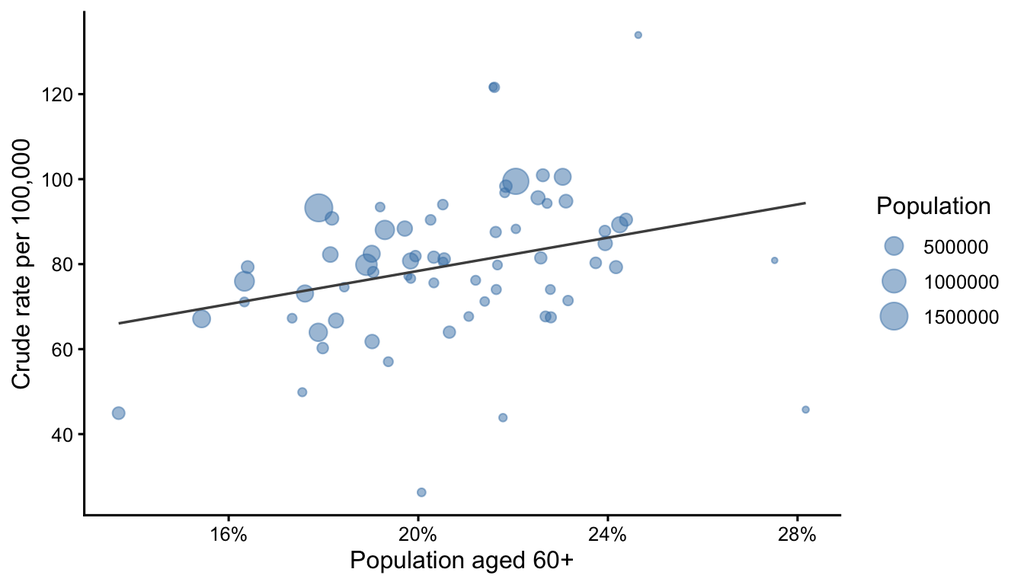

Figure 4: Crude rates partly track age structure.

```r
ggplot(county, aes(p60, crude)) +
  geom_point(aes(size = pop), alpha = 0.5, colour = "steelblue") +
  geom_smooth(method = "lm", se = FALSE, colour = "grey30", linewidth = 0.6) +
  scale_x_continuous(labels = scales::percent) +
  labs(x = "Population aged 60+", y = "Crude rate per 100,000", size = "Population")
```

The association is modest (r ≈ 0.3) — smoking and other exposures vary too — but it is enough to reorder counties, as we will see. Comparing crude rates thus confounds risk with demography. Standardization removes that confounding; here we use the indirect method, which gives the SMR.

# 4 Expected counts and the SMR

## 4.1 Expected counts

Ask how many cases each county *would have had* if every stratum in it experienced the statewide risk. Apply the **reference rates** $r_j$ to the **local population** $n_{ij}$:

$$E_i = \sum_j r_j\, n_{ij}, \qquad r_j = \frac{\sum_i O_{ij}}{\sum_i n_{ij}} .$$

Only the reference rates need to be stable, and they are computed from the whole state. Each county contributes nothing but its population counts.

```r
ref <- d |>
  group_by(race, gender, age) |>
  summarise(r_ref = sum(cases) / sum(population), .groups = "drop")  # 16 rates

E_tbl <- d |>
  left_join(ref, by = c("race", "gender", "age")) |>
  group_by(county) |>
  summarise(E = sum(population * r_ref))
```

`SpatialEpi::expected()` does the same thing, as in Moraga 5.2. It assumes the rows are sorted by area and then by strata **in the same order within every area**; nothing checks this for you.

```r
d_sorted <- d |> arrange(county, race, gender, age)

E_se <- expected(
  population = d_sorted$population,
  cases      = d_sorted$cases,
  n.strata   = 16
)

all.equal(E_tbl$E, E_se)                        # identical
```

```
[1] TRUE
```

Because the reference rates come from these same data (**internal** standardization), expected counts sum to observed counts:

```r
c(observed = sum(county$O), expected = sum(E_tbl$E))
```

```
observed expected
   10279    10279
```

## 4.2 The SIR (and the SMR)

$$\text{SIR}_i = \frac{O_i}{E_i}$$

An SIR of 1 means the county had as many cases as its demography predicts; 1.2 means 20% more; 0.8 means 20% fewer. For deaths the same ratio is called the **SMR**. The **indirectly standardized rate** puts it back on the rate scale: $\text{SIR}_i \times$ the reference crude rate.

```r
county <- county |>
  left_join(E_tbl, by = "county") |>
  mutate(
    SIR   = O / E,
    lower = qchisq(0.025, 2 * O) / (2 * E),          # exact Poisson 95% CI
    upper = qchisq(0.975, 2 * (O + 1)) / (2 * E)
  )

summary(county$SIR)
```

```
   Min. 1st Qu.  Median    Mean 3rd Qu.    Max.
 0.3203  0.8251  0.9555  0.9316  1.0590  1.3747
```

## 4.3 Mapping the SIR

An SIR has a natural midpoint at 1, so a diverging palette is defensible here (unlike most rates — recall Week 1). Breaks are symmetric on the ratio scale.

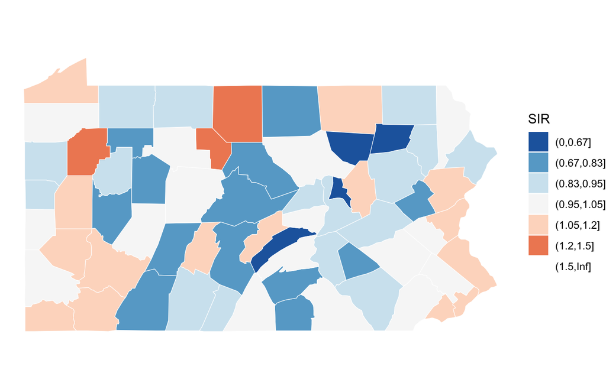

Figure 5: Raw SIRs for lung cancer, Pennsylvania 2002, standardized by race, sex, and age.

```r
pa_map <- pa |> left_join(county, by = "county")

sir_breaks <- c(0, 0.67, 0.83, 0.95, 1.05, 1.2, 1.5, Inf)

ggplot(pa_map) +
  geom_sf(aes(fill = cut(SIR, sir_breaks)), colour = "white", linewidth = 0.2) +
  scale_fill_brewer(palette = "RdBu", direction = -1, drop = FALSE, name = "SIR") +
  theme_void()
```

# 5 Crude rate versus SMR

The ranking of counties changes once age is accounted for:

```r
county |>
  mutate(rank_crude = rank(-crude), rank_SIR = rank(-SIR)) |>
  filter(county %in% c("schuylkill", "forest", "monroe", "bucks",
                       "philadelphia", "lehigh", "northampton")) |>
  transmute(county, p60 = round(p60, 3), crude = round(crude, 1),
            SIR = round(SIR, 2), rank_crude, rank_SIR)
```

| county | p60 | crude | SIR | rank_crude | rank_SIR |
| --- | --- | --- | --- | --- | --- |
| bucks | 0.163 | 76.0 | 1.06 | 43 | 18 |
| forest | 0.275 | 80.9 | 0.74 | 31 | 60 |
| lehigh | 0.198 | 80.7 | 0.97 | 32 | 29 |
| monroe | 0.164 | 79.3 | 1.10 | 37 | 10 |
| northampton | 0.197 | 88.4 | 1.06 | 19 | 16 |
| philadelphia | 0.179 | 93.2 | 1.16 | 14 | 5 |
| schuylkill | 0.244 | 90.5 | 0.92 | 16 | 39 |

Schuylkill has one of the higher crude rates in the state and an SIR below 1: an old population, not an unusual risk. Monroe and Bucks move the other way. Philadelphia’s crude rate is only modestly above the state average, yet its SIR ranks among the highest once its younger and more diverse population is accounted for.

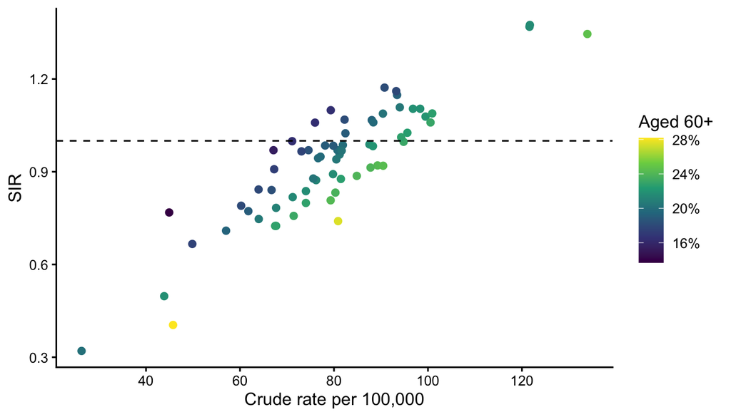

Figure 6: Crude rate vs. SIR, coloured by the share of the population aged 60+.

```r
ggplot(county, aes(crude, SIR)) +
  geom_point(aes(colour = p60), size = 2) +
  scale_colour_viridis_c(labels = scales::percent, name = "Aged 60+") +
  geom_hline(yintercept = 1, linetype = "dashed") +
  labs(x = "Crude rate per 100,000", y = "SIR")
```

At a given crude rate, older counties (yellow) sit lower on the SIR axis: part of their excess was expected from age alone.

**ImportantStrictly, SIRs compare each area to the reference — not to each other**

Each $E_i$ is built on area $i$’s own population structure, so two SIRs are strictly comparable only if the excess risk is roughly the same across age, sex, and race groups. In practice we map SIRs anyway, and the Bayesian models of Weeks 8–9 are built on $O_i$ and $E_i$; just do not over-read small differences between neighbouring counties.

## 5.1 Precision is not uniform

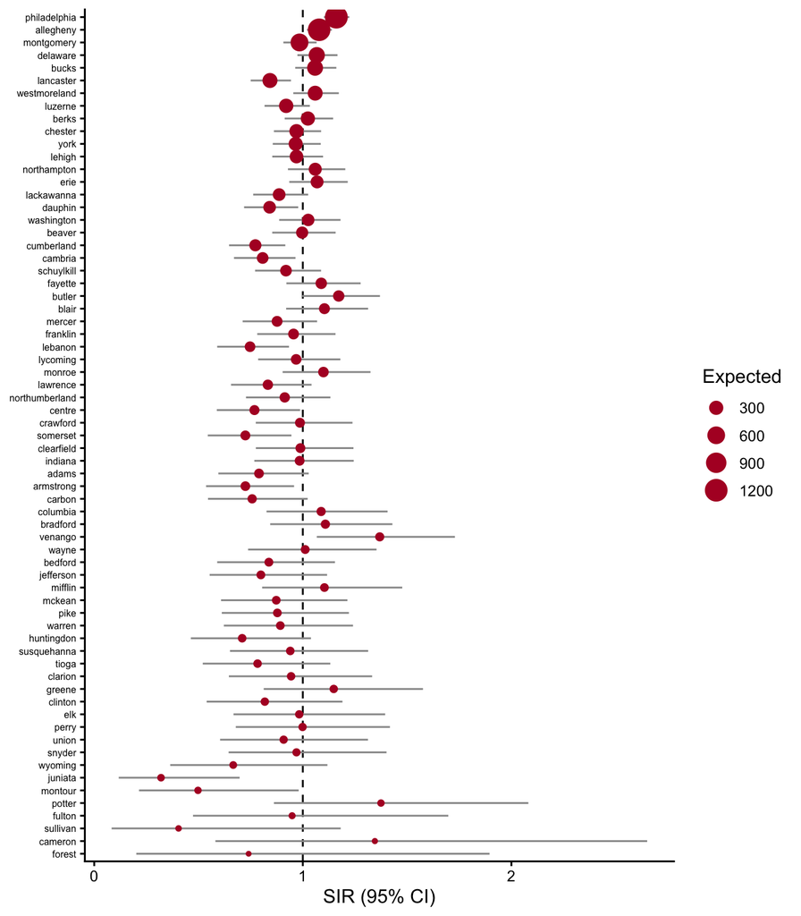

Figure 7: SIRs with exact 95% intervals, ordered by expected count.

```r
ggplot(county, aes(SIR, reorder(county, E))) +
  geom_vline(xintercept = 1, linetype = "dashed") +
  geom_linerange(aes(xmin = lower, xmax = upper), colour = "grey60") +
  geom_point(aes(size = E), colour = "#b2182b") +
  labs(x = "SIR (95% CI)", y = NULL, size = "Expected") +
  theme(axis.text.y = element_text(size = 6))
```

Forest, Cameron, and Sullivan each expect fewer than ten cases; their SIRs span most of the map’s colour range and their intervals span nearly all of the plausible range. Philadelphia and Allegheny expect over a thousand. The map colours them with the same confidence. That is Tuesday’s problem.

**NoteIf you use `spdep::probmap()`**

It returns expected counts and a relative risk, but `relRisk` is scaled by 100: a county at the reference level has `relRisk = 100`, not 1. Divide by 100 before comparing it with an SIR, or thresholds such as “SIR > 1.2” will flag nearly every county.

# At home exercise: fifteen minutes

1. For Lehigh and Northampton, write one sentence each interpreting the SIR, with its interval, for a county health officer.
2. Name one county whose SIR you would *not* put in a press release, and say why in one sentence.

# Key takeaways

1. Aggregate with `lengths(st_intersects(areas, points))`; always check that counts sum to the number of points and that zero-count areas survived.
2. A count map is a population map. Divide by the population at risk, and know whether that denominator is people, births, or person-time.
3. Crude rates confound risk with demographic structure.
4. $\text{SIR}_i = O_i / E_i$; its precision depends on $E_i$, which varies by orders of magnitude across areas.

# References

Breslow, N. E., & Day, N. E. (1987). *Statistical methods in cancer research. Volume II: The design and analysis of cohort studies*. IARC Scientific Publications No. 82, Ch. 2.

Moraga, P. (2019). *Geospatial health data: Modeling and visualization with R-INLA and Shiny*. Chapman & Hall/CRC, §5.2. https://www.paulamoraga.com/book-geospatial/

Rothman, K. J., Greenland, S., & Lash, T. L. (2008). *Modern epidemiology* (3rd ed.). Lippincott Williams & Wilkins, Ch. 3–4.

Waller, L. A., & Gotway, C. A. (2004). *Applied spatial statistics for public health data*. Wiley, Ch. 2.